# Análisis Multivariado de Datos

Análisis Exploratorio de Datos Multivariados

Mario José Pacheco López

2026-06-14

### Datos multivariados

*World Development Indicators | DataBank*

| Country | Region | Income | Inflation | GDP | Education | Sanitation | Health | Labor | Mortality | Urban |
| --- | --- | --- | --- | --- | --- | --- | --- | --- | --- | --- |
| ABW | Latin America & Caribbean | High income | 3.6260414 | 30082.1584 | 4.548764 | 98.68238 | NA | NA | NA | 62.53676 |
| AFG | Middle East & North Africa | Low income | 0.6261491 | 491.3372 | NA | 46.13354 | 14.208419 | NA | 58.3 | 24.99916 |
| AGO | Sub-Saharan Africa | Lower middle income | 19.6289380 | 2860.0936 | 2.183513 | 49.28652 | 2.298875 | NA | 36.0 | 65.87321 |
| ALB | Europe & Central Asia | Upper middle income | 2.0280596 | 5897.6545 | 3.082014 | 98.97365 | 6.590025 | 59.296 | 7.8 | 56.37700 |
| AND | Europe & Central Asia | High income | NA | 42819.7577 | 3.246720 | 100.00000 | 7.377811 | NA | 3.0 | 88.50810 |
| ARE | Middle East & North Africa | High income | 3.0686338 | 47135.3592 | NA | 99.10102 | 4.098542 | 81.012 | 5.3 | 84.86018 |
| ARG | Latin America & Caribbean | Upper middle income | 34.2772237 | 11752.7999 | 4.877740 | NA | 10.172893 | 59.595 | 9.1 | 91.76799 |
| ARM | Europe & Central Asia | Upper middle income | 2.5202338 | 4196.0056 | 2.113312 | 92.23585 | 10.005434 | 67.170 | 11.2 | 64.85028 |
| ASM | East Asia & Pacific | High income | NA | 12552.0547 | NA | 62.15130 | NA | NA | NA | 83.47800 |
| ATG | Latin America & Caribbean | High income | 1.2071579 | 18273.4271 | 2.269227 | 98.51369 | 4.686565 | 72.611 | 8.1 | 24.77814 |
| AUS | East Asia & Pacific | High income | 1.9114000 | 57410.1737 | NA | 99.99937 | 10.089075 | 65.746 | 3.2 | 87.22677 |
| AUT | Europe & Central Asia | High income | 1.9983798 | 51194.0750 | 5.254370 | 99.97282 | 10.515716 | 61.323 | 2.9 | 68.10468 |
| AZE | Europe & Central Asia | Upper middle income | 2.2685469 | 4739.7943 | 2.455430 | 91.69093 | 3.836613 | 66.300 | 17.5 | 57.18415 |
| BDI | Sub-Saharan Africa | Low income | -2.8146981 | 245.6617 | 5.078640 | 44.49544 | 7.293961 | NA | 37.0 | 17.68202 |
| BEL | Europe & Central Asia | High income | 2.0531650 | 47487.2100 | 6.388830 | 99.48618 | 10.993797 | 54.184 | 3.3 | 86.88834 |
| BEN | Sub-Saharan Africa | Lower middle income | 0.9191707 | 1151.7410 | 2.931620 | 18.19373 | 3.436498 | NA | 53.1 | 47.99528 |
| BFA | Sub-Saharan Africa | Low income | 1.9559430 | 777.4656 | 5.488610 | 25.68355 | 4.944277 | 44.893 | 51.7 | 26.08322 |
| BGD | South Asia | Lower middle income | 5.5436214 | 1965.2437 | 2.094775 | 55.80269 | 2.316222 | NA | 26.2 | 30.51757 |
| BGR | Europe & Central Asia | High income | 2.8145447 | 9849.3840 | 4.052010 | 86.01436 | 7.340863 | 55.323 | 5.8 | 73.60021 |
| BHR | Middle East & North Africa | High income | 2.0876694 | 26324.4067 | 2.388940 | 100.00000 | 3.943249 | NA | 6.4 | 100.00000 |
| BHS | Latin America & Caribbean | High income | 2.2658635 | 32642.3353 | 2.492641 | 93.71004 | 5.838903 | NA | 12.0 | 81.96432 |
| BIH | Europe & Central Asia | Upper middle income | 1.4171081 | 6047.8471 | 3.892970 | 95.38506 | 8.761004 | 41.905 | 6.0 | 48.97193 |
| BLR | Europe & Central Asia | Upper middle income | 4.8723022 | 6360.0375 | 4.836570 | 98.93920 | 5.526995 | 70.921 | 2.6 | 77.21327 |
| BLZ | Latin America & Caribbean | Upper middle income | 0.2699826 | 6011.9904 | 6.127800 | 84.05203 | 4.755299 | 67.295 | 11.7 | 43.16485 |
| BMU | North America | High income | NA | 113204.8221 | 1.935955 | 99.94165 | NA | NA | NA | 100.00000 |
| BOL | Latin America & Caribbean | Lower middle income | 2.2720599 | 4206.8553 | 8.015860 | 61.88638 | 6.603994 | 71.798 | 19.6 | 69.41339 |
| BRA | Latin America & Caribbean | Upper middle income | 3.6648503 | 9300.6607 | 6.088510 | 88.02503 | 9.464750 | 64.226 | 13.1 | 86.44207 |
| BRB | Latin America & Caribbean | High income | 3.1060057 | 21381.2426 | 5.404478 | 96.63894 | 5.830380 | 63.577 | 10.9 | 59.27018 |
| BRN | East Asia & Pacific | High income | 1.0250518 | 30988.1190 | NA | 94.61428 | 2.416009 | 65.395 | 9.1 | 74.81725 |
| BTN | South Asia | Lower middle income | 2.7239639 | 3400.2042 | 6.478110 | 77.23784 | 3.068967 | 62.603 | 19.1 | 38.46619 |
| BWA | Sub-Saharan Africa | Upper middle income | 3.2380156 | 7407.9594 | 7.905386 | 69.20699 | 6.040103 | NA | 38.7 | 66.15792 |
| CAF | Sub-Saharan Africa | Low income | 1.6121569 | 455.2440 | 1.565876 | 14.84784 | 10.994841 | NA | 73.9 | 41.28247 |
| CAN | North America | High income | 2.2682257 | 46539.1762 | 4.888990 | 98.84154 | 10.922621 | 65.795 | 4.5 | 81.55003 |
| CHE | Europe & Central Asia | High income | 0.9363355 | 85217.3692 | 4.930080 | 99.89987 | 11.198911 | 68.484 | 3.6 | 79.29222 |
| CHI | Europe & Central Asia | High income | NA | 60784.8125 | NA | NA | NA | NA | NA | 32.81260 |
| CHL | Latin America & Caribbean | High income | 2.4348898 | 15659.4809 | 5.473060 | 99.14830 | 9.150404 | 63.242 | 6.3 | 87.96205 |
| CHN | East Asia & Pacific | Upper middle income | 2.0747904 | 10085.6638 | NA | 89.69422 | 5.069333 | 70.255 | 6.4 | 61.50020 |
| CIV | Sub-Saharan Africa | Lower middle income | 0.4012978 | 2130.8662 | 3.211650 | 34.87089 | 3.091678 | NA | 53.5 | 50.87185 |
| CMR | Sub-Saharan Africa | Lower middle income | 1.0688581 | 1610.6964 | 3.030960 | 44.41486 | 3.619702 | NA | 48.0 | 53.63399 |
| COD | Sub-Saharan Africa | Low income | NA | 518.1696 | NA | 16.72563 | 3.241272 | NA | 55.8 | 42.49466 |
| COG | Sub-Saharan Africa | Lower middle income | 1.1527790 | 2694.4341 | 2.771670 | 20.26857 | 1.755850 | NA | 32.2 | 63.44346 |
| COL | Latin America & Caribbean | Upper middle income | 3.2405693 | 6816.9682 | 4.449100 | 91.35066 | 7.717775 | 65.237 | 12.7 | 77.28048 |
| COM | Sub-Saharan Africa | Lower middle income | 2.1515508 | 1527.4053 | NA | 50.15951 | 4.903186 | NA | 40.6 | 31.40736 |
| CPV | Sub-Saharan Africa | Upper middle income | 1.2561519 | 4294.9651 | 4.787923 | 76.72373 | 4.785482 | 55.600 | 14.1 | 70.39707 |
| CRI | Latin America & Caribbean | High income | 2.2211146 | 12590.2494 | 6.769930 | 97.70251 | 7.285877 | 62.210 | 7.8 | 76.55443 |
| CUB | Latin America & Caribbean | Upper middle income | NA | 8911.4621 | 8.024985 | 90.89865 | 11.018425 | NA | 5.2 | 77.01563 |
| CUW | Latin America & Caribbean | High income | 2.5836876 | 19119.1245 | 5.938733 | NA | NA | 55.800 | NA | 91.36013 |
| CYM | Latin America & Caribbean | High income | NA | 83865.5540 | 2.163769 | 83.35081 | NA | NA | NA | 100.00000 |
| CYP | Europe & Central Asia | High income | 1.4354912 | 29120.3750 | NA | 99.50949 | 6.784463 | 62.488 | 2.3 | 66.82555 |
| CZE | Europe & Central Asia | High income | 2.1494949 | 23705.9330 | 4.215410 | 99.07389 | 7.371736 | 60.563 | 2.5 | 72.84987 |

### Métodos multivariados

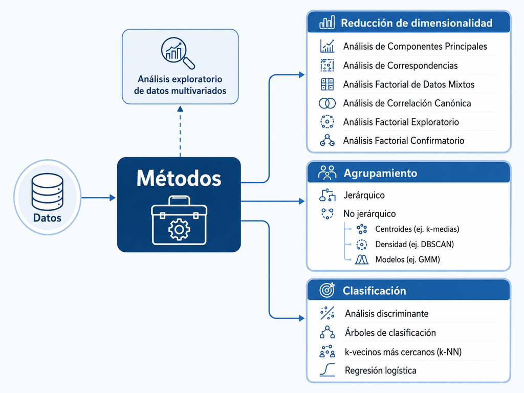

## Análisis exploratorio de datos multivariados

### Herramientas de análisis

- Medidas de centralidad multivariadas
- Medidas de co-variabilidad y correlación
- La distribución normal multivariada
  - Medidas de asimetría y curtosis
  - Pruebas de normalidad
  - Detección de datos atípicos
- Gráficos para datos multivariados
- Descripción de variables categóricas
- Descripción de datos faltantes

### Estructura de los datos

Considere una muestra aleatoria de $n$ vectores aleatorios
$$\boldsymbol{x}_{i}=\left(x_{i1},x_{i2},...,x_{ip}\right)^{\top},\;i=1,...,n,$$
que componen una matriz o base de datos de la forma
$$\boldsymbol{X}=\left[\begin{array}{c}
\boldsymbol{x}_{1}^{\top}\\
\boldsymbol{x}_{2}^{\top}\\
\vdots\\
\boldsymbol{x}_{n}^{\top}
\end{array}\right]=\left[\begin{array}{cccc}
x_{11} & x_{12} & \cdots & x_{1p}\\
x_{21} & x_{22} & \cdots & x_{2p}\\
\vdots & \vdots & & \vdots\\
x_{i1} & x_{i2} & \cdots & x_{ip}\\
\vdots & \vdots & & \vdots\\
x_{n1} & x_{n2} & \cdots & x_{np}
\end{array}\right]$$

### Medidas de centralidad multivariadas

**Vector de promedios**:
$$\bar{\boldsymbol{x}}=\left(\bar{x}_{1},\bar{x}_{2},...,\bar{x}_{p}\right)^{\top}$$

**Vector de medianas** muestrales univariadas:
$$\tilde{\boldsymbol{x}}=\left(\tilde{x}_{1},\tilde{x}_{2},...,\tilde{x}_{p}\right)^{\top}$$

**Mediana muestral multivariada** (*L1-median* o mediana espacial):
$$\tilde{\boldsymbol{x}}_{m}=\underset{\boldsymbol{a}}{\text{argmin}}\left\{ \sum_{i=1}^{n}\left\Vert \boldsymbol{x}_{i}-\boldsymbol{a}\right\Vert _{2}\right\} ,\quad\boldsymbol{a}\in\mathbb{R}^{p}$$
con $\left\Vert \boldsymbol{x}_{i}-\boldsymbol{a}\right\Vert _{2}^{2}=\sum_{j=1}^{p}\left(x_{ij}-a_{j}\right)^{2}$

### Medidas de centralidad multivariadas

- Use el *vector de promedios* para resumir la localización central conjunta de variables cuantitativas cuando no hay valores atípicos influyentes.
- Use el *vector de medianas* muestrales univariadas para resumir la localización central componente a componente cuando hay asimetría o valores atípicos influyentes.
- Use la *mediana muestral multivariada* para resumir la localización central conjunta de datos multivariados cuando se requiere una medida robusta del centro global frente a valores atípicos o asimetría.

### Medidas de co-variabilidad y correlación

**Matriz de covarianzas**:
$$S=\left[\begin{array}{cccc}
s_{1}^{2} & s_{12} & \cdots & s_{1p}\\
s_{21} & s_{2}^{2} & \cdots & s_{2p}\\
\vdots & \vdots & \ddots & \vdots\\
s_{p1} & s_{p2} & \cdots & s_{p}^{2}
\end{array}\right],$$
donde
$$s_{jk} =\frac{\sum_{i=1}^{n}x_{ij}x_{ik}-n\bar{x}_{j}\bar{x}_{k}}{n-1}, ~ ~j,k=1,2,...,p,$$
es la **covarianza** entre las variables $j$ y $k$. En particular, $s_{jj}=s^2_j$ es la **varianza** de la variable $j$-ésima y $s_j = \sqrt{s_{jj}}$ es la **desviación estándar**.

### Medidas de co-variabilidad y correlación

**Matriz de correlaciones** (de *Pearson*):
$$R=\left[\begin{array}{cccc}
1 & r_{12} & \cdots & r_{1p}\\
r_{21} & 1 & \cdots & r_{2p}\\
\vdots & \vdots & \ddots & \vdots\\
r_{p1} & r_{p2} & \cdots & 1
\end{array}\right],$$
donde
$$r_{jk} =\frac{s_{jk}}{s_{j}s_{k}},~~ j,k=1,2,...,p,$$
con $-1\le r_{jk}\le 1$, $\forall j,k$, es la **correlación** entre las variables $j$ y $k$.

### Medidas de co-variabilidad y correlación

**Correlaciones parciales**:
$$r_{jk\mid S} =\frac{\sum_{i=1}^n{\hat\epsilon_{ji}\hat\epsilon_{ki}}}{\sqrt{\sum_{i=1}^n{\hat\epsilon_{ji}^2}\sum_{i=1}^n{\hat\epsilon_{ki}^2}}},\quad j\neq k, \text{y } S=\{1,2,...,p\}\setminus\{j,k\},$$
donde $\hat\epsilon_{ij}=x_{ij}-\hat{x}_{ij}$, $\hat\epsilon_{ik}=x_{ik}-\hat{x}_{ik}$ y
$$\begin{aligned}
\hat{x}_{ij} &= \hat\alpha_j + \sum_{s\in S}{\hat\beta_sx_{is}}\\
\hat{x}_{ik} &= \hat\alpha_k + \sum_{s\in S}{\hat\gamma_sx_{is}}
\end{aligned}$$

### Medidas de co-variabilidad y correlación

**Varianza generalizada**:
$$V_G=\mid S\mid$$

**Varianza total**:
$$V_T=\text{tr}\left(S\right)={\displaystyle \sum_{j=1}^{p}}s_{j}^{2}$$

### Medidas de co-variabilidad y correlación

**Coeficiente de correlación de rangos**:
$$r_{jk} = \frac{\sum_{i=1}^n\sum_{l=1}^n a_{j,il}b_{k,il}}{\sqrt{\sum_{i=1}^n\sum_{l=1}^n a_{j,il}^2 \sum_{i=1}^n\sum_{l=1}^n b_{k,il}^2}}, \ \ -1\le r_{jk} \le 1,$$
donde $a_{j,il}$ y $b_{k,il}$ son *score* para las variables $j$ y $k$, respectivamente, tales que $a_{j,il}=-a_{j,li}$, $b_{k,il}=-b_{k,li}$ y $a_{j,ii} = b_{k,ii} = 0$.

### Medidas de co-variabilidad y correlación

**Coeficiente de correlación de *Spearman*** :

Se definen $a_{j,il}$ y $b_{k,il}$ como
$$\begin{aligned}
a_{j,il} &= u_{j,l} - u_{j,i} \\
b_{k,il} &= v_{k,l} - v_{k,i}
\end{aligned}$$
donde $u_{j,i}$ y $v_{k,i}$, $(i=1,2,...,n)$, corresponden a los rangos de los valores observados de las variables $j$ y $k$, respectivamente.

### Medidas de co-variabilidad y correlación

**Coeficiente de correlación de *Kendall*** :

Se calculan $a_{j,il}$ y $b_{k,il}$ como
$$\begin{aligned}
a_{j,il} &= sgn(u_{j,l} - u_{j,i}) \\
b_{k,il} &= sgn(v_{k,l} - v_{k,i})
\end{aligned}$$
donde $u_{j,i}$ y $v_{k,i}$, $(i=1,2,...,n)$, corresponden a los rangos de los valores observados de las variables $j$ y $k$, respectivamente.

### Medidas de co-variabilidad y correlación

**Covarianza de distancia**: sean $\boldsymbol{x}_i$, y $\boldsymbol{y}_i$, $i=1,2,...,n$, $n$ vectores de valores observados de las variables $X\in \mathbb{R}^p$ y $Y\in \mathbb{R}^q$,
$$cov_d(\boldsymbol{x},\boldsymbol{y})=\frac{1}{n}\sqrt{\sum_{i=1}^n\sum_{k=1}^n A_{ik}B_{ik}},$$
donde
$$\begin{aligned}
a_{ik}=\mid\mid \boldsymbol{x}_i-\boldsymbol{x}_k \mid\mid ~ ; \quad
b_{ik}=\mid\mid \boldsymbol{y}_i-\boldsymbol{y}_k \mid\mid
\end{aligned}$$
y
$$\begin{aligned}
A_{ik}=a_{ik}-\bar{a}_{i\cdot}-\bar{a}_{\cdot k} + \bar{a}_{\cdot\cdot} \\
B_{ik}=b_{ik}-\bar{b}_{i\cdot}-\bar{b}_{\cdot k} + \bar{b}_{\cdot\cdot}
\end{aligned}$$

### Medidas de co-variabilidad y correlación

**Correlación de distancia**:
$$cor_d(\boldsymbol{x},\boldsymbol{y}) = \frac{cov_d(\boldsymbol{x},\boldsymbol{y})}{\sqrt{var_d(\boldsymbol{x})var_d(\boldsymbol{y})}},$$
con $var_d(\boldsymbol{x})=cov_d(\boldsymbol{x},\boldsymbol{x})$

### Medidas de co-variabilidad y correlación

- Use la *matriz de covarianzas* para resumir la variabilidad y la asociación lineal conjunta entre variables cuando interesa conservar sus escalas originales.
- Use la *matriz de correlaciones* para resumir la asociación lineal conjunta entre variables cuando sus escalas difieren o interesa compararlas en forma estandarizada.
- Use las *correlaciones parciales* para medir la asociación lineal entre dos variables controlando el efecto de las demás, cuando interesa distinguir relaciones directas de asociaciones inducidas por otras variables.
- Use la *varianza generalizada* para resumir la dispersión global multivariada cuando interesa cuantificar el volumen de variación conjunta de las variables.

### Medidas de co-variabilidad y correlación

- Use la *varianza total* para resumir la dispersión global multivariada cuando interesa cuantificar la variabilidad total acumulada de las variables, entendida como la suma de sus varianzas.
- Use el *coeficiente de correlación de Spearman* para medir la asociación monótona entre dos variables cuando la relación no es necesariamente lineal o los datos contienen asimetría, atípicos o nivel de medición ordinal.
- Use el *coeficiente de correlación de Kendall* para medir la asociación monótona entre dos variables cuando interesa una medida basada en concordancias y discordancias, especialmente útil con datos ordinales, muestras pequeñas o empates.
- Use la *correlación de distancia* para medir la intensidad de la dependencia entre dos variables o dos grupos de variables, incluso si la relación no es lineal; vale cero si y solo si son independientes.

### La distribución normal multivariada

Un vector aleatorio $\boldsymbol{X}$ $\left(p\times1\right)$ tiene distribución normal multivariada, $\boldsymbol{X}\sim N_{p}\left(\boldsymbol{\mu},\Sigma\right)$, si su función de densidad de probabilidad (*fdp*) está dada por
$$f_{\boldsymbol{X}}\left(\boldsymbol{x}\right)=\frac{1}{\left(2\pi\right)^{p/2}\left|\Sigma\right|^{1/2}}\exp\left\{ -\frac{1}{2}\left(\boldsymbol{x}-\boldsymbol{\mu}\right)^{\top}\Sigma^{-1}\left(\boldsymbol{x}-\boldsymbol{\mu}\right)\right\},~~ \boldsymbol{x}\in \mathbb{R}^p,$$
donde

- $E\left(\boldsymbol{X}\right)=\boldsymbol{\mu}\in\mathbb{R}^{p}$, es el **vector de medias** de $\boldsymbol{X}$
- $Cov\left(\boldsymbol{X}\right)=E\left(\boldsymbol{X}\boldsymbol{X}^\top\right)-\boldsymbol{\mu}\boldsymbol{\mu}^\top$ $=\Sigma\succeq 0$, $\left(\Sigma=\Sigma^\top\right)$, es la **matriz de covarianzas** de $\boldsymbol{X}$.

### La distribución normal multivariada

Por ejemplo, el vector aleatorio $\boldsymbol{X}$, tal que
$$\boldsymbol{X}\sim N_2\left(\boldsymbol{\mu}, \Sigma\right)$$
con

$$\boldsymbol{\mu} = \left[\begin{array}{c} 3.0\\ 1.0\\
\end{array}\right], \ \ \ \ \Sigma = \left[\begin{array}{rr}
2.0 & -1.5\\
-1.5 & 3.0\\
\end{array}\right]$$

### La distribución normal multivariada

Función de densidad de probabilidad

[interactive chart not shown]

Contornos de la distribución

[interactive chart not shown]

### La distribución normal multivariada

**Asimetría y curtosis**:
$$\begin{aligned}
b_{1,p} &=\frac{1}{n^{2}}\sum_{i=1}^{n}\sum_{l=1}^{n}\left[\left(\boldsymbol{x}_{i}-\bar{\boldsymbol{x}}\right)^{\top}S^{-1}\left(\boldsymbol{x}_{l}-\bar{\boldsymbol{x}}\right)\right]^{3}\quad\text{(asimetría)}\\
b_{2,p} &=\frac{1}{n}\sum_{i=1}^{n}\left[\left(\boldsymbol{x}_{i}-\bar{\boldsymbol{x}}\right)^{\top}S^{-1}\left(\boldsymbol{x}_{i}-\bar{\boldsymbol{x}}\right)\right]^{2}\quad\qquad\text{(curtosis)}
\end{aligned}$$
Se espera que en el caso de una distribución normal $b_{1,p}=0$ (simétrica) y $b_{2,p}=p\left(p+2\right)$ (mesocúrtica).

### La distribución normal multivariada

**Gráfico cuantil-cuantil multivariado**: para cada individuo se calcula
$$d_{i}^2=\left(\boldsymbol{X}_{i}-\bar{\boldsymbol{X}}\right)^{\top}S^{-1}\left(\boldsymbol{X}_{i}-\bar{\boldsymbol{X}}\right),\ \ i=1,2,...,n,$$
que bajo el supuesto de normalidad multivariada, sigue una distribución $\chi^2_{p}$. Luego, se calculan los estadísticos de orden $d_{(1)}^2,d_{(2)}^2,...,d_{(n)}^2$.

Finalmente, se grafica la nube de puntos conformada por las parejas $\left(q_i,d_{(i)}^2\right)$, y se agrega la línea $d_{(i)}^2 = a + bq_i$ que “mejor” se ajusta a la nube de puntos.

### La distribución normal multivariada

**Prueba de Mardia**: estamos interesados en contrastar las hipótesis
$$\begin{aligned}
H_0&:\text{los datos provienen de una distribución normal multivariada}\\
H_a&:\text{los datos no provienen de una distribución normal multivariada}
\end{aligned}$$
Se calculan las estadísticas
$$\begin{aligned}
Z_{1} &=\frac{n\left(p+1\right)\left(n+1\right)\left(n+3\right)}{6\left[n\left(n+1\right)\left(p+1\right)-6\right]}b_{1,p}\\
Z_{2} &=\frac{b_{2,p}-p\left(p+2\right)}{\sqrt{8p\left(p+2\right)/n}}
\end{aligned}$$
donde, bajo $H_0$, $Z_1\sim\chi_{p\left(p+1\right)\left(p+2\right)/6}^{2}$ y $Z_2 \sim N\left(0,1\right)$, para así, rechazar la hipótesis de normalidad multivariada al nivel de significancia $\alpha$ en términos de asimetría si $Z_{1}\ge\chi_{\alpha,p\left(p+1\right)\left(p+2\right)/6}^{2}$ o de curtosis si $\left|Z_{2}\right|\ge Z_{\alpha/2}$.

### La distribución normal multivariada

Otras pruebas de normalidad multivariada:

- *test* de Henze-Zirkler
- *test* de Royston (extensión del *test* de Shapiro-Wilk)
- *test* de Doornik-Hansen
- *test* de Energía

### Gráficos para datos multivariados

- Gráficos de dispersión
- Diagramas de caja bivariados (*bagplot*)
- Gráficos de densidades empíricas bivariadas
- Gráficos de contornos

### Descripción de variables categóricas

**Tabla de contingencia**:

$$\boldsymbol{N}=
\left[\begin{array}{cccccc}
n_{11} & n_{12} & \cdots & n_{1j} & \cdots & n_{1q}\\
n_{21} & n_{22} & \cdots & n_{2j} & \cdots & n_{2q}\\
\vdots & \vdots & & \vdots & & \vdots\\
n_{i1} & n_{i2} & \cdots & n_{ij} & \cdots & n_{iq}\\
\vdots & \vdots & & \vdots & & \vdots\\
n_{p1} & n_{p2} & \cdots & n_{pj} & \cdots & n_{pq}
\end{array}\right]_{\left(p\times q\right)},$$
donde $n_{ij}$ corresponde al número de individuos en las categorías $i=1,2,...,p$ y $j=1,2,...,q$ de las variables categóricas representadas en las filas y columnas de la tabla, respectivamente.

### Descripción de variables categóricas

**Frecuencias condicionales fila**:
$$\boldsymbol{P_f}=
\left[\begin{array}{cccccc}
p_{11\mid1} & p_{12\mid1} & \cdots & p_{1j\mid1} & \cdots & p_{1q\mid1}\\
p_{21\mid2} & p_{22\mid2} & \cdots & p_{2j\mid2} & \cdots & p_{2q\mid2}\\
\vdots & \vdots & & \vdots & & \vdots\\
p_{i1\mid i} & p_{i2\mid i} & \cdots & p_{ij\mid i} & \cdots & p_{iq\mid i}\\
\vdots & \vdots & & \vdots & & \vdots\\
p_{p1\mid p} & p_{p2\mid p} & \cdots & p_{pj\mid p} & \cdots & p_{pq\mid p}
\end{array}\right]_{\left(p\times q\right)},$$
donde $p_{ij\mid i}=n_{ij}/n_{i\cdot}$, con $n_{i\cdot} = \sum_{j=1}^q n_{ij}$, es la proporción de individuos en la categoría $i$-ésima de la variable fila. Similarmente, se pueden calcular las frecuencias condicionales columna.

### Descripción de variables categóricas

**Prueba de independencia**:

- Se quiere probar la independencia ($H_{0}$) entre un par de variables categóricas
- Se calcula la estadística *chi*-cuadrado,
  $$\chi^{2}=\sum_{i=1}^{p}\sum_{j=1}^{q}\frac{\left(n_{ij}-E_{ij}\right)^{2}}{E_{ij}}\overset{\text{ind}}{\sim}\chi_{\left(p-1\right)\left(q-1\right)}^{2},$$
  donde $E_{ij}=n_{i\cdot}n_{\cdot j}/n$, con $n=\sum_{i=1}^p\sum_{j=1}^q n_{ij}$, es el número esperado de individuos bajo independencia
- Se rechaza $H_{0}$, al nivel de significancia $\alpha$ si $\chi^{2}>\chi_{\alpha,\left(p-1\right)\left(q-1\right)}^{2}$.

### Descripción de variables categóricas

**Medidas de asociación**:

- Coeficiente de Contingencia $(C)$:

$$C = \sqrt{\frac{k}{k-1}\frac{\chi^2}{n+\chi^2}},\ \ 0\le C \le 1,$$
con $k=\min\{p,q\}$.

- Coeficiente $V$ de *Crámer*:

$$V = \sqrt{\frac{\chi^2}{n(k-1)}},\ \ 0\le V\le 1$$

### Descripción de variables categóricas

- Use el *coeficiente de contingencia* para resumir la intensidad global de asociación entre dos variables categóricas en una tabla de contingencia, teniendo en cuenta que su valor máximo depende del tamaño de la tabla.
- Use el *coeficiente V de Cramér* para medir la intensidad de la asociación entre dos variables categóricas en una tabla de contingencia, cuando se requiere una medida estandarizada comparable entre tablas de distinto tamaño.

### Descripción de datos faltantes

- Estructura de los datos faltantes en la matriz de datos: cómo se ubican los datos faltantes en la matriz de observaciones y variables, considerando su distribución general, concentración y localización.
- Magnitud de los datos faltantes y pérdida de información: cantidad de datos faltantes a nivel global, por variable y por unidad.
- Patrones de datos faltantes en estructuras multivariadas: configuración conjunta de la ausencia entre variables, identificando combinaciones recurrentes y formas estructuradas de falta.

### Descripción de datos faltantes

- Mecanismos de datos faltantes:
  - Faltantes completamente aleatorios (*MCAR*): la probabilidad de que un dato falte no depende ni del valor faltante ni de las variables observadas.
  - Faltantes aleatorios (*MAR*): la probabilidad de que un dato falte puede depender de variables observadas, pero no del valor faltante una vez condicionadas esas variables.
  - Faltantes no aleatorios (*MNAR*): la probabilidad de que un dato falte depende del propio valor faltante, incluso después de considerar las variables observadas.